# Analysis of Uni- and Multi-Dimensional Contours with GAMs and Functional PCA: an Application to Ultrasound Tongue Imaging

## 1.7 (x, y) ~ knot: FPCA

Here we implement the multivariate approach with FPCA. The advantage here is that while the FPCA model is multivariate, PC scores control multiple dimensions jointly, here `x` and `y`. This means that the following linear model `lm(score ~ Category)` is not any more complicated than in the univariate case. The code that follows is based on the [ex2D.R](https://github.com/uasolo/FPCA-phonetics-workshop/tree/master/scripts) script.

**(x, y) ~ knot: FPCA fit**

```r
# construct a multiFunData object
curvesFun2D <- lapply(c("x", "y"), function(Pos)
  long2irregFunData(raw_curves,
                    id = "frame_id",
                    time = "knot",
                    value = {{Pos}}) %>%
    as.funData()
) %>%
  multiFunData()
curvesFun2D
```

```
An object of class "multiFunData"
[[1]]
Functional data with 60 observations of 1-dimensional support
argvals:
    1 2 ... 11      (11 sampling points)
X:
    array of size 60 x 11

[[2]]
Functional data with 60 observations of 1-dimensional support
argvals:
    1 2 ... 11      (11 sampling points)
X:
    array of size 60 x 11
```

```r
# Compute FPCA
mfpca <- MFPCA(curvesFun2D,
               # computing more PCs than we will use:
               # a quick way to get a good approx for the % explained var per PC
               M = 5,
               uniExpansions = list(list(type = "uFPCA"),list(type = "uFPCA"))
)
# Prop of explained var
PropExpVar <- round(mfpca$values  / sum( mfpca$values) , digits = 3)
```

Multivariate FPCA is computed by the function `MFPCA::MFPCA()`. The first two PCs explain 69.1% and 23.2% of the variance.

**(x, y) ~ knot: FPCA curves**

```r
nPC <- 2
# scores st. dev.
sdFun <- mfpca$values %>% sqrt()
# PC curves to be plotted
PCcurves <- expand_grid(PC = 1:nPC,
                        Dim = 1:2,
                        fractionOfStDev = seq(-1, 1, by=.25)) %>%
  group_by(PC, Dim, fractionOfStDev) %>%
  reframe(
    funData2long1(
      mfpca$meanFunction[[Dim]] +
        fractionOfStDev * sdFun[PC] * mfpca$functions[[Dim]][PC],
      time= "knot", value = "Pos")
  ) %>%
  mutate(Dim = factor(Dim, levels = c(1,2), labels = c('x', 'y')))
# Plot
FPCA_knot_curves_plot <- ggplot(PCcurves) +
  aes(x = knot, y = Pos, group = fractionOfStDev, color = fractionOfStDev) +
  geom_line() +
  scale_color_gradient2(low = "blue", mid = "grey", high = "orangered",
                        breaks = c(-1, 0 , 1)) +
  facet_grid(Dim ~ PC,
             scales = "free_y",
             labeller = labeller(PC = ~ str_glue("PC{.x}"))) +
  labs(color = expression(frac(s[k], sigma[k]))) +
  theme(legend.position = "right",
        axis.title.y = element_blank())

FPCA_knot_traj_plot <- ggplot(PCcurves %>% pivot_wider(names_from = Dim, values_from = Pos)) +
  aes(x = x, y = y, group = fractionOfStDev, color = fractionOfStDev) +
  geom_path() +
  geom_point(color = 'black') +
  scale_color_gradient2(low = "blue", mid = "grey", high = "orangered",
                        breaks = c(-1, 0 , 1)) +
  facet_grid(. ~ PC,
             # scales = "free_y",
             labeller = labeller(PC = ~ str_glue("PC{.x}"))) +
  labs(color = expression(frac(s[k], sigma[k]))) +
  theme(legend.position = "right")
```

Figure 14: First 2 PCs: effect of scores on contour shape, separated by dimension x, y

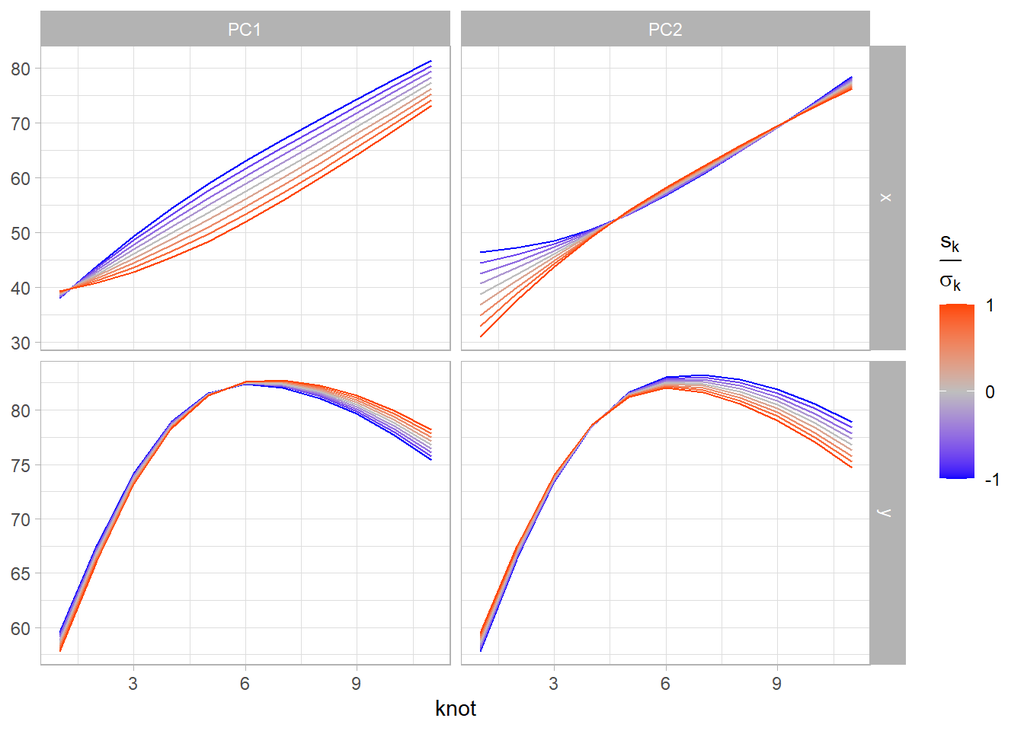

```r
FPCA_knot_curves_plot
```

Figure 15: First 2 PCs: effect of scores on contour shape, (x,y) trajectory version

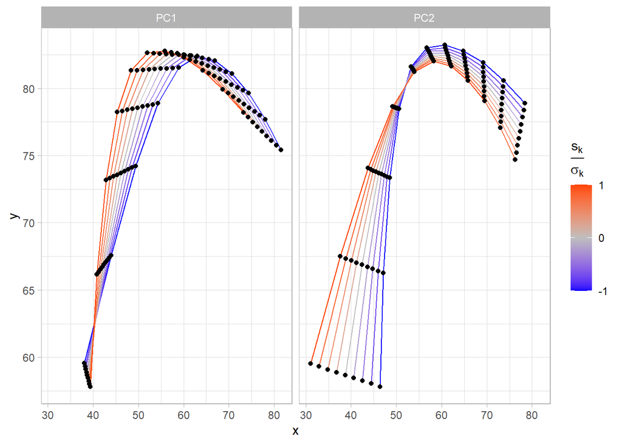

```r
FPCA_knot_traj_plot
```

The first plot is an explicit representation of the `(x, y) ~ knot` model, while the second one eliminates the `knot` axis, with knots marked as black points.

Comparing this result with the one obtained with the angle-based approach (Figure 7), we see that the first two PCs are similar but swapped, this time the variation in the middle part of the contour explains more variance than the variation on the left. It is reassuring that both geometrical parametrizations lead to the same qualitative conclusion that these two types of variation are present in the data and that they are independent. The swapping is probably a consequence of the different parametrization, which results in a different computation of variance.

Given what we know from the angle-based analysis, we expect now that PC1 is the component that describes the variation connected to `Category`, which means that `s1` is the score that will be used in the linear regression.

**(x, y) ~ knot: FPCA lm and predictions**

```r
# collect PC scores
PCscores <- mfpca$scores[, 1:nPC] %>%
  `colnames<-`( paste0("s", 1:nPC)) %>%
  as_tibble() %>%
  bind_cols(raw_curves %>% distinct(frame_id, Category), .)

# boxplots PC scores by Category
FPCA_knot_scores_plot <- PCscores %>%
  pivot_longer(cols = paste0("s", 1:nPC),
               names_to = "PC", values_to = "score") %>%
  ggplot() +
  aes(x = Category, y = score, color = Category) +
  geom_boxplot() +
  facet_wrap(~ PC) +
  scale_color_manual(values=Category.colors) +
  theme(legend.position = "bottom")

s <- 1 # score index
model_eq <- str_glue("s{s} ~ Category") %>% as.formula()
mod <- lm(model_eq, data = PCscores)
mod %>% summary()
```

```
Call:
lm(formula = model_eq, data = PCscores)

Residuals:
    Min      1Q  Median      3Q     Max
-9.8873 -3.3157 -0.5061  3.4827  8.8519

Coefficients:
            Estimate Std. Error t value Pr(>|t|)
(Intercept) -13.4100     0.8715  -15.39   <2e-16 ***
CategoryB    27.2800     1.2325   22.13   <2e-16 ***
---
Signif. codes:  0 '***' 0.001 '**' 0.01 '*' 0.05 '.' 0.1 ' ' 1

Residual standard error: 4.773 on 58 degrees of freedom
Multiple R-squared:  0.8941,    Adjusted R-squared:  0.8923
F-statistic: 489.9 on 1 and 58 DF,  p-value: < 2.2e-16
```

```r
emmeans(mod, pairwise ~ Category)
```

```
$emmeans
 Category emmean    SE df lower.CL upper.CL
 A         -13.4 0.872 58    -15.2    -11.7
 B          13.9 0.872 58     12.1     15.6

Confidence level used: 0.95

$contrasts
 contrast estimate   SE df t.ratio p.value
 A - B       -27.3 1.23 58 -22.134  <.0001
```

```r
# reconstruct predicted curves
predCurves <- emmeans(mod, pairwise ~ Category)$emmeans %>%
  as_tibble() %>%
  expand_grid(Dim = 1:2) %>%
  group_by(Category, Dim) %>%
  reframe(bind_cols(
    funData2long1(mfpca$meanFunction[[Dim]] +
                    emmean * mfpca$functions[[Dim]][s], time = "knot", value = "Pos"),
    funData2long1(mfpca$meanFunction[[Dim]] +
                    lower.CL * mfpca$functions[[Dim]][s], time = "knot", value = "Pos_l") %>%
      select(Pos_l),
    funData2long1(mfpca$meanFunction[[Dim]] +
                    upper.CL * mfpca$functions[[Dim]][s], time = "knot", value = "Pos_u") %>%
      select(Pos_u)
  )) %>%
  mutate(Dim = factor(Dim, levels = c(1,2), labels = c('x', 'y'))) %>%
  pivot_wider(names_from = Dim, values_from = starts_with("Pos"))


FPCA_knot_pred_plot <- ggplot(predCurves) +
  aes(group = Category, color = Category) +
  geom_path(aes(x = Pos_x, y = Pos_y)) +
  geom_path(aes(x = Pos_l_x, y = Pos_l_y), linetype = "dotted") +
  geom_path(aes(x = Pos_u_x, y = Pos_u_y), linetype = "dotted") +
  scale_color_manual(values=Category.colors) +
  xlab("x") + ylab("y") +
  theme(legend.position = "bottom")
```

Figure 16: Distribution of the first 2 PC scores by Category

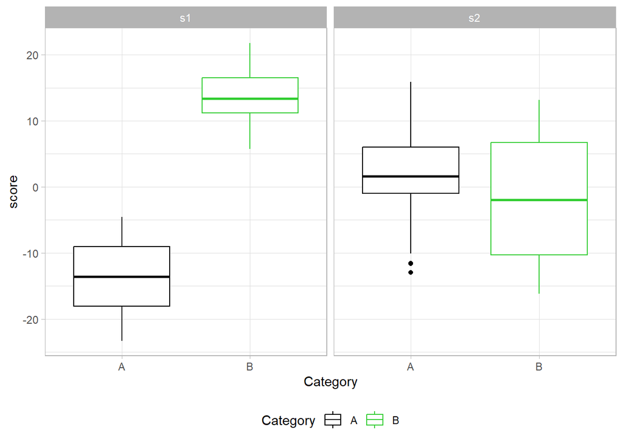

```r
FPCA_knot_scores_plot
```

Figure 17: Reconstructed contours by Category, based on regression model: s1 ~ Category

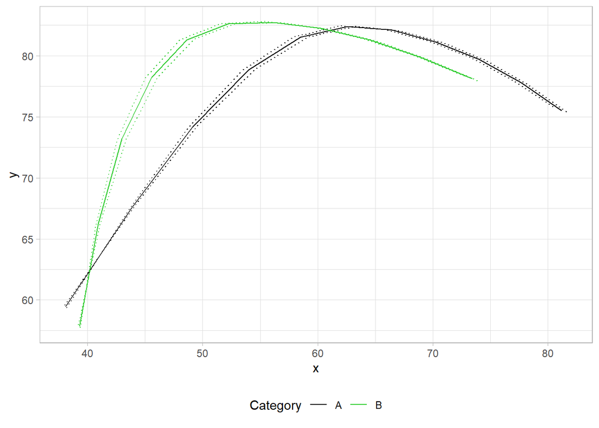

```r
FPCA_knot_pred_plot
```

# 2 Dynamic analysis

With a dynamic analysis, we are adding one extra independent axis to the picture, the `time` axis. All considerations regarding the difference between the angle-based and the knot-based geometrical parametrization remain the same. What changes is that the model **support** becomes two-dimensional: `angle * time` or `knot * time`. This means that data are organized on a two-dimensional grid, while in the static analysis data were organized on a uni-dimensional grid along `angle` or `knot`. The response variables are the same as in the static case. In the angle-based case, the response variable is `radius`, while in the knot-based case, the response variables are `x` and `y`, i.e. a multivariate model.

In the following, we will focus mainly on the practical aspects concerning the change in the support dimensionality.

## 2.1 Dataset

The dataset for the dynamic analysis consists of 60 artificial tongue contour sequences, or clips, 30 for each `Category`, `A` and `B`. Each clip is sampled along the normalized time axis `normTime` on a 6-points regular grid : 0, 0.2, 0.4, 0.6, 0.8, 1.0. Below two example clips, one for each `Category`.

**Dataset generation**

```r
set.seed(12)
normTime_grid <- (0:5)/5
N_curves_per_Category <- 30
raw_curves <- tibble(
  Category = c('A', 'B'),
  a_left = c(1.2, 1.2),
  a_right = c(0.2, 0.8),
  a_left_off = c(0, 0),
  a_right_off = c(0.6, -0.6),
  theta_off = c(-pi/12, 0),
  scale_x_off = c(1,1),
  centre_x_off = c(0,0),
  centre_y_off = c(0,0)
) %>%
  expand_grid(i = 1:N_curves_per_Category) %>%
  rownames_to_column(var = "clip_id") %>%
  mutate(frame_id = as.integer(clip_id)) %>%
  select(-i) %>%
  mutate(across(c(Category, clip_id), ~ factor(.x))) %>%
  expand_grid(normTime = normTime_grid) %>%
  group_by(Category, clip_id, normTime) %>%
  reframe(parab_tongue(
    a_left = a_left + a_left_off * cur_group()$normTime + runif(1, 0, 0),
    a_right = a_right + a_right_off * cur_group()$normTime + runif(1, 0, 0),
    centre = c(50 + centre_x_off + runif(1, 0, 2),
               80 + centre_y_off + runif(1, 0, 2)),
    theta = pi/18 + theta_off,
    scale =  c(10 * scale_x_off * runif(1, 1/1.1, 1.1), 5)
  ))

# one sample clip per Category
set.seed(123)
dataset_clip_ex <- raw_curves %>%
  group_by(Category) %>%
  distinct(clip_id) %>%
  slice_sample(n=1) %>%
  ungroup() %>%
  inner_join(raw_curves, by = c("Category", "clip_id")) %>%
  ggplot() +
  aes(x, y, group = normTime, color = normTime) +
  geom_path() +
  facet_grid(~ Category, labeller = label_both) +
  theme(legend.position = "bottom")
```

Figure 18: Dynamic dataset, one example clip per Category

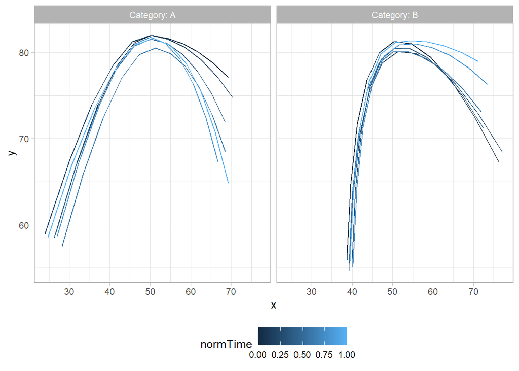

```r
dataset_clip_ex
```

The trends are clear: the tongue tip moves downward in `Category A` and upward in `B`, while the tongue root is tilted differently in the two categories but it does not change in time. These easy patterns are useful to get familiar with the complexity of the models that will be built in this section.

## 2.2 radius ~ angle * time: GAM

Like in the static case, we compute polar coordinates and we apply Procrustean interpolation to the `angle` axis. The time axis (`normTime`) is sampled at regular intervals and it does not need any treatment. In a realistic scenario, one may need to carry out some form of normalization or even time warping to the time axis as well, prior starting the analysis.

Below two example clips, one for each `Category`, after computation of polar coordinates. The first plot is a representation faithful to the data form, i.e. at each location on the two-dimensional grid support (`angle * normTime`) corresponds one response value (`radius`). The second plot (polar coordinates) reflects the geometry of the problem.

```r
# convert to polar
origin <-  c(70, 30) # eye inspection
raw_curves  <- raw_curves  %>%
  cart2polar(origin, 'x', 'y')

angle_range <- raw_curves  %>%
  filter(knot %in% range(knot)) %>% # first and last knot
  group_by(knot) %>%
  summarise(median_angle = median(angle)) %>%
  pull(median_angle) %>%
  sort()

angle_grid <- seq(angle_range[1], angle_range[2], length.out=11)

curves  <- raw_curves  %>%
  group_by(Category, clip_id, normTime) %>%
  # interpolation
  reframe(bind_cols(
    knot = seq_along(angle_grid), # fake knots, needed for AR1 term in GAM
    approx(angle, radius, angle_grid, rule = 2) %>% as_tibble()
    )) %>%
  rename(angle = x,radius = y)

set.seed(123)
dataset_clip_ex_flat <- curves %>%
  group_by(Category) %>%
  distinct(clip_id) %>%
  slice_sample(n=1) %>%
  ungroup() %>%
  inner_join(curves, by = c("Category", "clip_id")) %>%
  ggplot() +
  aes(x = angle, y= normTime) +
  geom_raster(aes(fill = radius)) +
  facet_grid(~ Category, labeller = label_both) +
  scale_x_reverse() +
  scale_fill_gradientn(colours = terrain.colors(10))

set.seed(123)
dataset_clip_ex_polar <- curves %>%
  group_by(Category) %>%
  distinct(clip_id) %>%
  slice_sample(n=1) %>%
  ungroup() %>%
  inner_join(curves, by = c("Category", "clip_id")) %>%
  ggplot() +
  aes(angle, radius, group = normTime, color = normTime) +
  geom_path() +
  facet_grid(~ Category, labeller = label_both) +
  radial_plot(60) +
  theme(legend.position = "bottom")
```

Figure 19: Dynamic dataset, one example clip per Category, flat version of polar coordinates

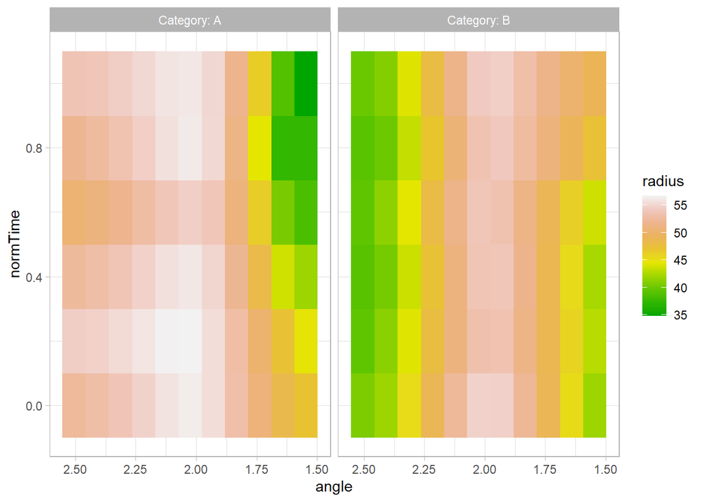

```r
dataset_clip_ex_flat
```

Figure 20: Dynamic dataset, one example clip per Category, polar coordinates

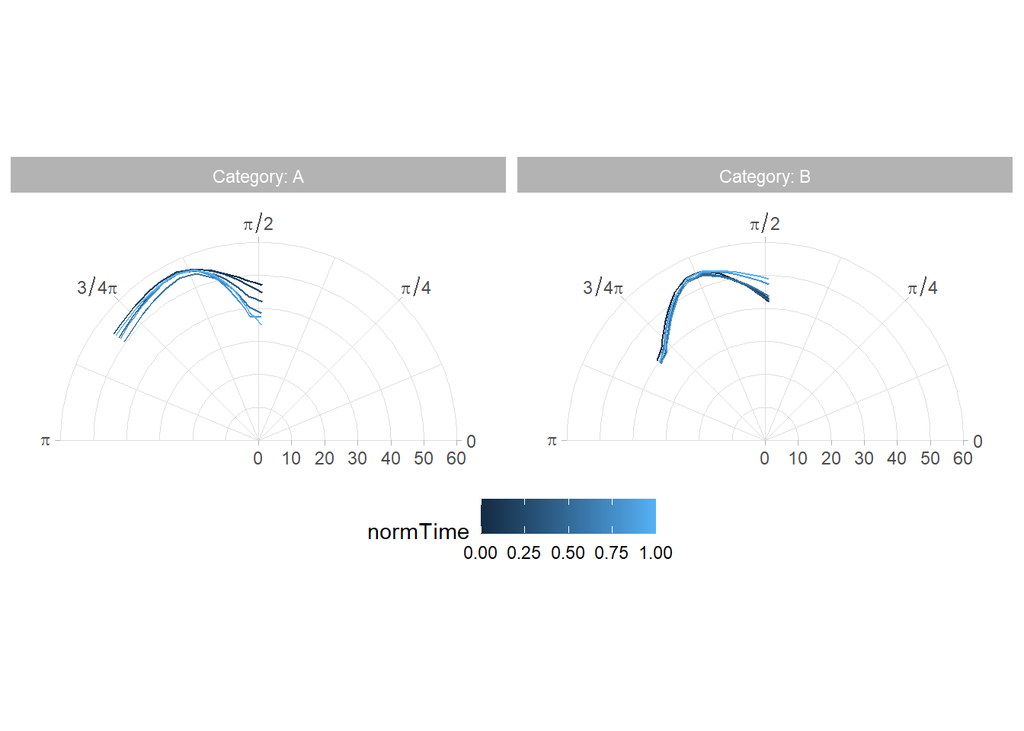

```r
dataset_clip_ex_polar
```

The GAM we build is similar to the one in Section 1.4, the only difference being that the uni-dimensional support smooth term `s(angle, by = Category)` is substituted by a two-dimensional support smooth term `te(angle, normTime, by = Category)`.

**radius ~ angle * time: GAM fit**

```r
gam_formula <- "radius ~ Category + te(angle, normTime, by = Category)"
discrete <- TRUE
family <- 'scat'
GAM <- bam(gam_formula %>% as.formula(),
            discrete=discrete,
            family=family,
            rho = 0,
            AR.start = curves %>% pull(knot)  == 1,
            data = curves
)
AR1.rho <- acf_resid(GAM, plot = FALSE)[2]
GAM <- bam(gam_formula %>% as.formula(),
            discrete=discrete,
            family=family,
            rho = AR1.rho,
            AR.start = curves %>% pull(knot)  == 1,
            data = curves
)
summary(GAM)
```

```
Family: Scaled t(6.219,0.809)
Link function: identity

Formula:
radius ~ Category + te(angle, normTime, by = Category)

Parametric coefficients:
            Estimate Std. Error t value Pr(>|t|)
(Intercept) 50.88693    0.04009 1269.24   <2e-16 ***
CategoryB   -2.76738    0.05673  -48.78   <2e-16 ***
---
Signif. codes:  0 '***' 0.001 '**' 0.01 '*' 0.05 '.' 0.1 ' ' 1

Approximate significance of smooth terms:
                                edf Ref.df    F p-value
te(angle,normTime):CategoryA  8.992   9.00 4028  <2e-16 ***
te(angle,normTime):CategoryB 13.790  15.94 2147  <2e-16 ***
---
Signif. codes:  0 '***' 0.001 '**' 0.01 '*' 0.05 '.' 0.1 ' ' 1

R-sq.(adj) =  0.965   Deviance explained = 87.8%
fREML = 5189.4  Scale est. = 1         n = 3960
```

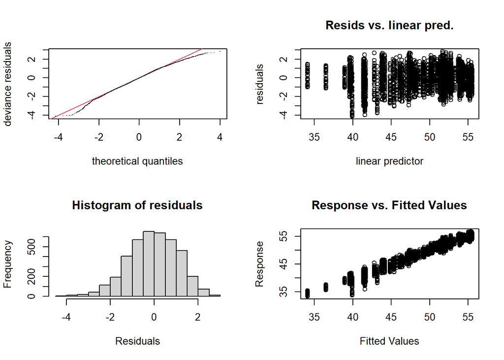

```
Method: fREML   Optimizer: perf chol
$grad
[1] -1.051534e-07 -2.727225e-05 -5.080956e-09  1.044912e-08

$hess
              [,1]          [,2]          [,3]          [,4]
[1,]  2.992828e+00  1.207520e-07 -7.946417e-22  1.233167e-20
[2,]  1.207520e-07  2.581570e-05  6.477271e-27 -1.005177e-25
[3,] -2.214410e-22  1.953008e-27  2.995126e+00  4.367715e-03
[4,] -8.045313e-21 -1.328408e-25  4.367715e-03  1.480643e+00

Model rank =  50 / 50

Basis dimension (k) checking results. Low p-value (k-index<1) may
indicate that k is too low, especially if edf is close to k'.

                                k'   edf k-index p-value
te(angle,normTime):CategoryA 24.00  8.99    0.92  <2e-16 ***
te(angle,normTime):CategoryB 24.00 13.79    0.92  <2e-16 ***
---
Signif. codes:  0 '***' 0.001 '**' 0.01 '*' 0.05 '.' 0.1 ' ' 1
```

```r
gam.check(GAM)
```

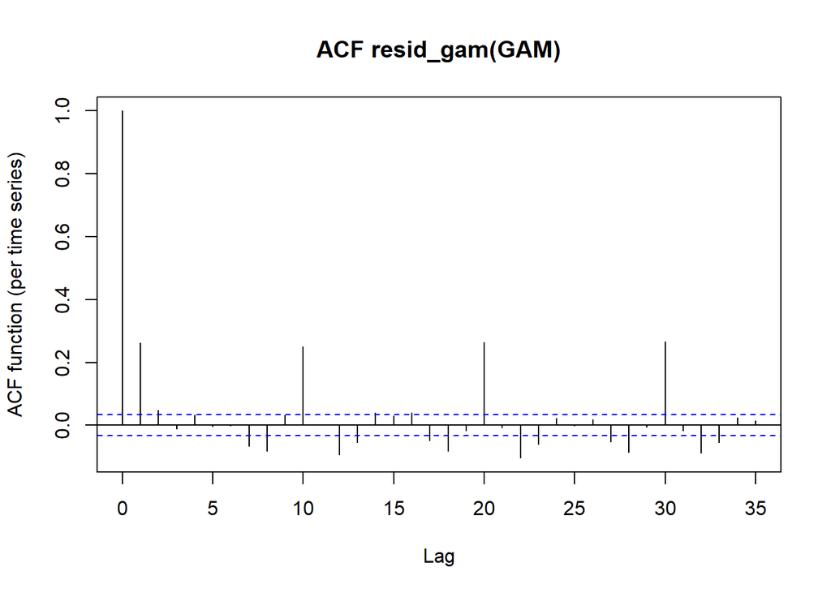

```r
acf_resid(GAM)
```

```r
angle_grid_plot <- angle_grid
pred <- get_predictions(GAM,
                        cond = list(angle = angle_grid_plot,
                                    normTime = normTime_grid,
                                    Category = c("A", "B")),
                        print.summary = FALSE)

gam_polar_time_flat_plot <- ggplot(pred) +
  aes(x = angle, y= normTime) +
  geom_raster(aes(fill = fit)) +
  facet_grid(~ Category, labeller = label_both) +
  scale_x_reverse() +
  scale_fill_gradientn(colours = terrain.colors(10))

gam_polar_time_polar_plot <- ggplot(pred) +
  aes(x = angle, y = fit, group = normTime, color = normTime) +
  geom_path() +
  facet_grid(~ Category, labeller = label_both) +
  radial_plot(60) +
  theme(legend.position = "bottom")
```

Figure 21: GAM predictions - flat version

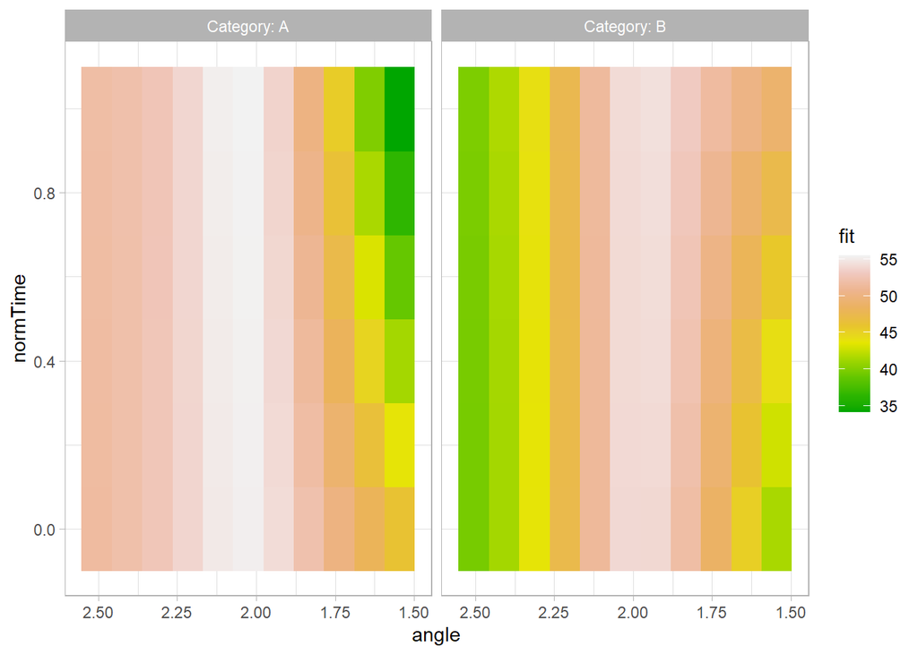

```r
gam_polar_time_flat_plot
```

Figure 22: GAM predictions - polar version

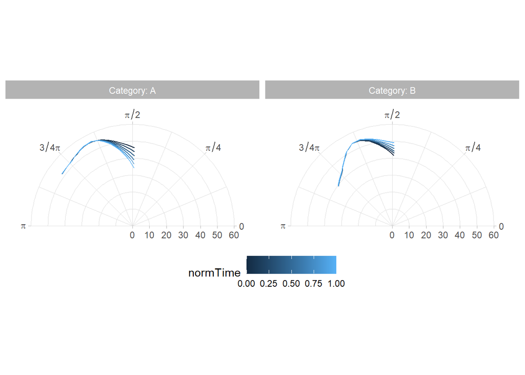

```r
gam_polar_time_polar_plot
```

Predictions capture the main trends faithfully.

### 2.2.1 Section predictions across time or angle

Let us take two sections, one at a fixed angle ($\pi/2$, around tongue tip) along time, another at a fixed time (at 0.5, half way through the gesture) along the angle axis.

**Cross-sections**

```r
sec_angle <- pi/2
pred <- get_predictions(GAM,
                        cond = list(angle = sec_angle,
                                    normTime = normTime_grid,
                                    Category = c("A", "B")),
                        print.summary = FALSE)
sec_angle_plot <- ggplot(pred) +
  aes(x = normTime, y = fit, group = Category ) +
  geom_line(mapping = aes(color = Category)) +
  scale_color_manual(values=Category.colors) +
  scale_fill_manual(values=Category.colors) +
  geom_ribbon(mapping = aes(ymin = fit - CI, ymax = fit + CI, fill = Category), alpha = 0.5) +
  theme_light() +
  ylab("Radius") +
  theme(legend.position = "bottom")

sec_time <- 0.5
pred <- get_predictions(GAM,
                        cond = list(angle = angle_grid_plot,
                                    normTime = sec_time,
                                    Category = c("A", "B")),
                        print.summary = FALSE)
sec_time_plot <- ggplot(pred) +
  aes(x = angle, y = fit, group = Category ) +
  geom_line(mapping = aes(color = Category)) +
  scale_color_manual(values=Category.colors) +
  scale_fill_manual(values=Category.colors) +
  geom_ribbon(mapping = aes(ymin = fit - CI, ymax = fit + CI, fill = Category), alpha = 0.5) +
  theme_light() +
  radial_plot(60) +
  theme(legend.position = "bottom")
```

Figure 23: Cross-section of GAM predictions at angle $\pi/2$

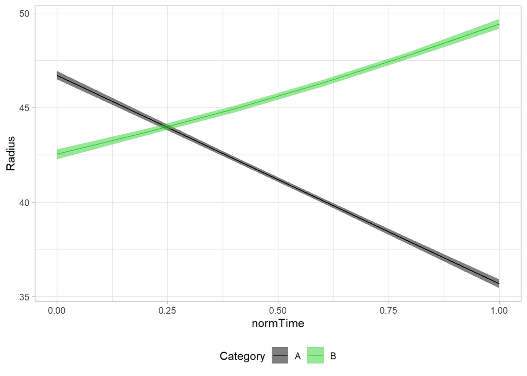

```r
sec_angle_plot
```

Figure 24: Cross-section of GAM predictions at normalized time 0.5

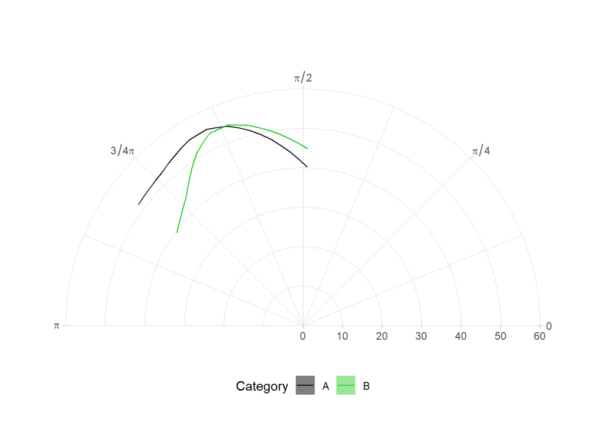

```r
sec_time_plot
```

### 2.2.2 Testing for significance: binary surfaces

Similarly to the static case (Section 1.4.3), we use binary smooths, in this case a binary surface, to quantify statistical significance between `Category` `A` and `B`. Below we plot the difference surface, where the dashed contours indicate where the difference is significant.

**Binary surfaces**

```r
curves <- curves %>%
  mutate(IsB = (Category == 'B') * 1)
gam_formula <- "radius ~ te(angle, normTime) + te(angle, normTime, by = IsB)"
GAM <- bam(gam_formula %>% as.formula(),
            discrete=discrete,
            family=family,
            rho = AR1.rho,
            AR.start = curves %>% pull(knot)  == 1,
            data = curves
)
summary(GAM)
```

```
Family: Scaled t(6.229,0.809)
Link function: identity

Formula:
radius ~ te(angle, normTime) + te(angle, normTime, by = IsB)

Parametric coefficients:
            Estimate Std. Error t value Pr(>|t|)
(Intercept) 50.88610    0.04002    1272   <2e-16 ***
---
Signif. codes:  0 '***' 0.001 '**' 0.01 '*' 0.05 '.' 0.1 ' ' 1

Approximate significance of smooth terms:
                          edf Ref.df    F p-value
te(angle,normTime)      8.992   9.00 4030  <2e-16 ***
te(angle,normTime):IsB 14.773  16.96 1541  <2e-16 ***
---
Signif. codes:  0 '***' 0.001 '**' 0.01 '*' 0.05 '.' 0.1 ' ' 1

R-sq.(adj) =  0.965   Deviance explained = 87.8%
fREML = 5182.2  Scale est. = 1         n = 3960
```

```r
pred_diff <-get_modelterm(GAM, 2, se = TRUE,
                          as.data.frame = TRUE, print.summary = FALSE) %>%
  mutate(signif = 1 * (fit + 1.96 * se.fit < 0 | fit - 1.96 * se.fit > 0))

max_diff <- max(abs(range(pred_diff$fit)))
diff_plot_GAM_angle_time <- ggplot(pred_diff) +
  aes(x = angle, y= normTime) +
  geom_raster(aes(fill = fit)) +
  scale_x_reverse() +
  scale_fill_gradient2(low = "blue", mid = "white", high = "orangered",
                        breaks = c(-1 * round(max_diff), 0 , round(max_diff)),
                       name = "Radius difference") +
  geom_contour(mapping = aes(x = angle, y= normTime, z = signif), breaks = 1, color = "black", linetype = "dashed")
```

Figure 25: Difference surface B - A

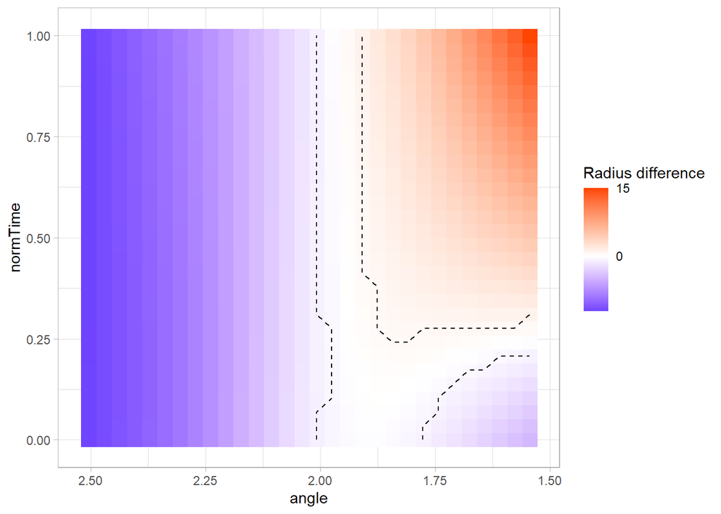

```r
diff_plot_GAM_angle_time
```

The plot shows that `B` is always lower than `A` on the left, i.e. tongue root has a smaller radius for `B` than for `A`, while on the right (tongue tip) the radius difference varies along time, according to the patterns in Figure 21 and Figure 22.

## 2.3 radius ~ angle * time: FPCA

The same geometrical setup as in Section 2.2 is applied here to PCA followed by linear regression. As it is always the case, the FPCA model changes with the geometrical setup, while linear regression remains in the geometry-agnostic form `lm(score ~ Category)`.

The FPCA code consists in first organising the dataset into a two-dimensional support `funData` object, then computing FPCA with `MFPCA::MFPCA()`. The twist here is that while this is a univariate model, we have to use `MFPCA()` and not `PACE()`. The reason is that `PACE()` does not accept multidimensional supports. The model is then a ‘multi’-variate one with only one response.

**radius ~ angle * time: FPCA fit**

```r
# build a funData object
nClips <- curves$clip_id %>% n_distinct()
argvals <- list(normTime=normTime_grid, angle=angle_grid)
# X: array of dim c(nClips, length(normTime_grid), length(angle_grid))
X <- curves %>%
  pivot_wider(id_cols = c(clip_id, normTime), names_from = angle, values_from = radius) %>%
  select(-normTime) %>%
  nest(.by = clip_id) %>%
  pull(data) %>%
  lapply(as.matrix) %>%
  abind(along = 0)
curvesFun <- funData(argvals, X)
curvesFun
```

```
Functional data with 60 observations of 2-dimensional support
argvals:
    0 0.2 ... 1     (6 sampling points)
    1.545106 1.64118 ... 2.505843       (11 sampling points)
X:
    array of size 60 x 6 x 11
```

```r
# FCP_TPA
fpca <- MFPCA(curvesFun %>% multiFunData(),
              M = 5,
              # FCP_TPA is one of the possible multidim. support parametrizations
              uniExpansions = list(list(type = "FCP_TPA",
                                        npc = 5,
                                        alphaRange = list(v = c(10^-2, 10^2), w = c(10^-3, 10^3))))
)

# Prop of explained var
PropExpVar <- round(fpca$values  / sum( fpca$values) , digits = 3)

nPC <- 2

# scores st. dev.
sdFun <- fpca$values %>% sqrt()

# PC curves to be plotted
PCcurves <- expand_grid(PC = 1:nPC,
                        fractionOfStDev = c(-1, 0, 1)) %>%
  group_by(PC, fractionOfStDev) %>%
  reframe(
    (fpca$meanFunction[[1]]@X[1,,] + fractionOfStDev * sdFun[PC] * fpca$functions[[1]]@X[PC,,]) %>%
      `colnames<-`(angle_grid) %>%
      as_tibble() %>%
      bind_cols(normTime = normTime_grid)
  ) %>%
  pivot_longer(cols = -c(PC, fractionOfStDev, normTime), names_to = "angle", values_to = "radius") %>%
  mutate(angle = as.numeric(angle))

# Plot
FPCA_angle_time_curves_plot <- ggplot(PCcurves %>% rename(`score/std` = fractionOfStDev)) +
  aes(x = angle, y = radius, group = normTime, color = normTime) +
  geom_path() +
  facet_grid(PC ~ `score/std`,
             labeller = labeller(PC = ~ str_glue("PC{.x}"), `score/std` = label_both),
             ) +
  radial_plot(60) +
  theme(legend.position = "bottom")
```

Figure 26: First 2 PCs: effect of scores on contour evolution in time

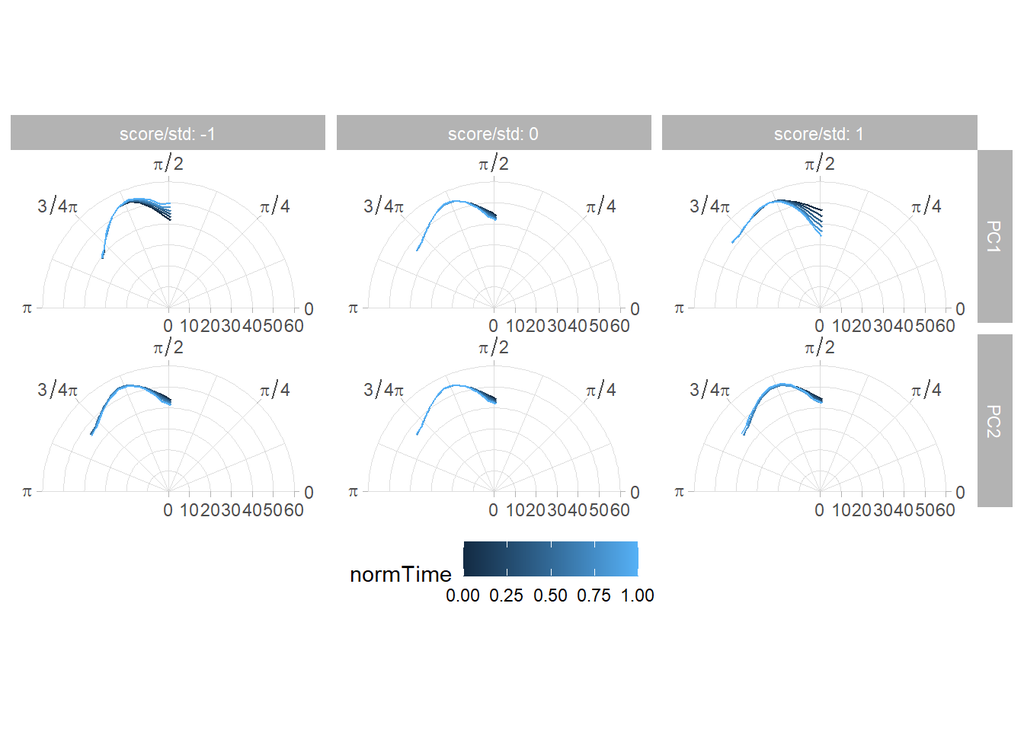

```r
FPCA_angle_time_curves_plot
```

PC1 explains 98.4% of the variance, PC2 explains 0.7% of the variance. To avoid cluttering, the variability modulated by the scores is represented only by three values of standard deviation-normalized scores: -1, 0 and 1. For example, the top left quadrant shows the clip reconstructed by taking the mean clip and subtracting the first PC multiplied by one standard deviation of `s1`.

Clearly, PC1 is capturing the variability in the right part of the contour (tongue tip), which is the one correlated with `Category`. This is confirmed by the PC scores boxplots below.

**radius ~ angle * time: FPCA predictions**

```r
# collect PC scores
PCscores <- fpca$scores[, 1:nPC] %>%
  `colnames<-`(paste0("s", 1:nPC)) %>%
  as_tibble() %>%
  bind_cols(curves %>% distinct(clip_id, Category), .)

# boxplots PC scores by Category
FPCA_angle_time_scores_plot <- PCscores %>%
  pivot_longer(cols = paste0("s", 1:nPC),
               names_to = "PC", values_to = "score") %>%
  filter(PC %in% str_c("s", 1:nPC)) %>%
  ggplot() +
  aes(x = Category, y = score, color = Category) +
  geom_boxplot() +
  facet_wrap(~ PC) +
  scale_color_manual(values=Category.colors) +
  theme(legend.position = "bottom")

s <- 1 # score index
model_eq <- str_glue("s{s} ~ Category") %>% as.formula()
mod <- lm(model_eq, data = PCscores)
mod %>% summary()
```

```
Call:
lm(formula = model_eq, data = PCscores)

Residuals:
     Min       1Q   Median       3Q      Max
-0.38541 -0.18281 -0.00389  0.16257  0.55832

Coefficients:
            Estimate Std. Error t value Pr(>|t|)
(Intercept)  3.13439    0.03898   80.41   <2e-16 ***
CategoryB   -6.26877    0.05513 -113.71   <2e-16 ***
---
Signif. codes:  0 '***' 0.001 '**' 0.01 '*' 0.05 '.' 0.1 ' ' 1

Residual standard error: 0.2135 on 58 degrees of freedom
Multiple R-squared:  0.9955,    Adjusted R-squared:  0.9955
F-statistic: 1.293e+04 on 1 and 58 DF,  p-value: < 2.2e-16
```

```r
emmeans(mod, pairwise ~ Category)
```

```
$emmeans
 Category emmean    SE df lower.CL upper.CL
 A          3.13 0.039 58     3.06     3.21
 B         -3.13 0.039 58    -3.21    -3.06

Confidence level used: 0.95

$contrasts
 contrast estimate     SE df t.ratio p.value
 A - B        6.27 0.0551 58 113.710  <.0001
```

```r
predCurves <- emmeans(mod, pairwise ~ Category)$emmeans %>%
  as_tibble() %>%
  group_by(Category) %>%
reframe(
    (fpca$meanFunction[[1]]@X[1,,] + emmean * fpca$functions[[1]]@X[s,,]) %>%
      `colnames<-`(angle_grid) %>%
      as_tibble() %>%
      bind_cols(normTime = normTime_grid)
  ) %>%
  pivot_longer(cols = -c(Category, normTime), names_to = "angle", values_to = "radius") %>%
  mutate(angle = as.numeric(angle))

FPCA_angle_time_pred_plot <- ggplot(predCurves) +
  aes(x = angle, y = radius, group = normTime, color = normTime) +
  geom_path() +
  facet_grid(~ Category, labeller = label_both) +
  radial_plot(60) +
  theme(legend.position = "bottom")
```

Figure 27: Distribution of the first 2 PC scores by Category

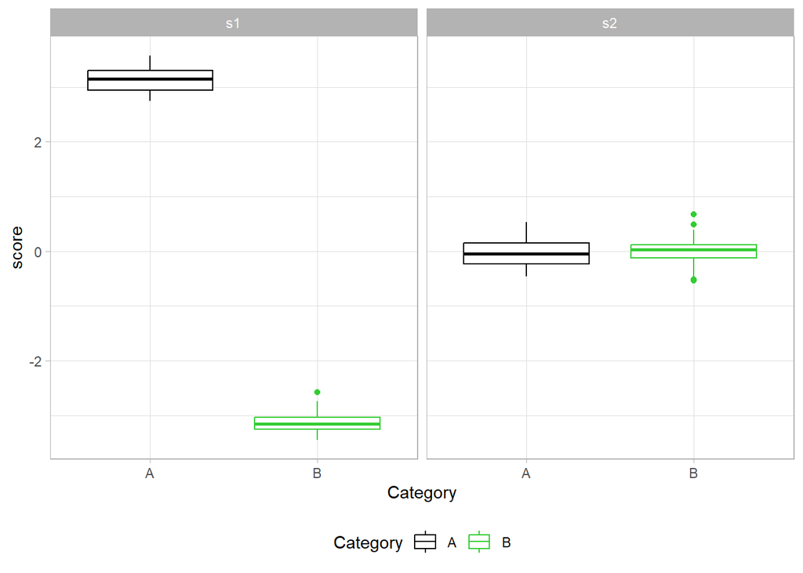

```r
FPCA_angle_time_scores_plot
```

A linear regression model predicting `s1` from `Category` is then fitted, which provides the predicted clips below.

Figure 28: Reconstructed clips by Category, based on regression model: s1 ~ Category

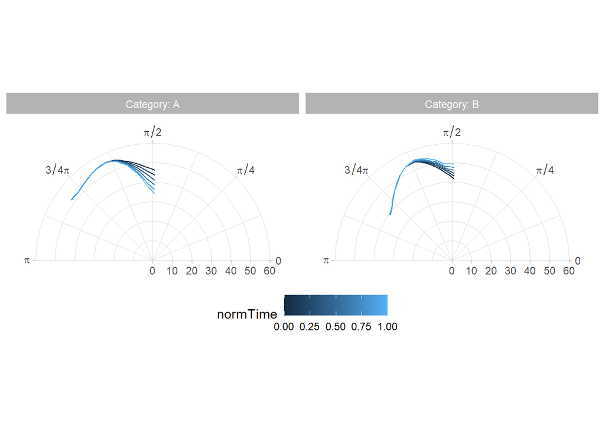

```r
FPCA_angle_time_pred_plot
```

## 2.4 (x, y) ~ knot * time: GAM

Left as exercise. In short, any term that in Section 1.6 looks like `s(knot, by = Category)` should be turned into `te(knot, normTime, by = Category)`.

## 2.5 (x, y) ~ knot * time: FPCA

This is the most complex model in this tutorial. Data objects have a two-dimensional support, (`knot` by `normTime`), the FPCA model is multivariate, as it takes values in `x` and `y`. The linear model following FPCA remains simple and geometry-agnostic.

**(x, y) ~ knot * time: FPCA fit and predict**

```r
# build a funData object
nClips <- raw_curves$clip_id %>% n_distinct()
argvals <- list(normTime=normTime_grid, knot=1:11)
# curvesFun is a multiFunData with two response outcomes (x, y),
# each of which is an array of dim c(nClips, length(normTime_grid), number of knots)
curvesFun <- multiFunData(
                     lapply(c('x', 'y'), function(Dim) {
                       funData(argvals,
                       raw_curves %>%
                         pivot_wider(id_cols = c(clip_id, normTime), names_from = knot, values_from = {{Dim}}) %>%
                         select(-normTime) %>%
                         nest(.by = clip_id) %>%
                         pull(data) %>%
                         lapply(as.matrix) %>%
                         abind(along = 0)
                     )}))
curvesFun
```

```
An object of class "multiFunData"
[[1]]
Functional data with 60 observations of 2-dimensional support
argvals:
    0 0.2 ... 1     (6 sampling points)
    1 2 ... 11      (11 sampling points)
X:
    array of size 60 x 6 x 11

[[2]]
Functional data with 60 observations of 2-dimensional support
argvals:
    0 0.2 ... 1     (6 sampling points)
    1 2 ... 11      (11 sampling points)
X:
    array of size 60 x 6 x 11
```

```r
# FCP_TPA
# the same base expansion applied to x and y
uniExpansion <- list(type = "FCP_TPA",
                                        npc = 5,
                                        alphaRange = list(v = c(10^-2, 10^2), w = c(10^-3, 10^3)))
fpca <- MFPCA(curvesFun,
              M = 5,
              uniExpansions = list(uniExpansion, uniExpansion)
)

# Prop of explained var
PropExpVar <- round(fpca$values  / sum( fpca$values) , digits = 3)


nPC <- 2
# scores st. dev.
sdFun <- fpca$values %>% sqrt()

# PC curves to be plotted
PCcurves <- expand_grid(PC = 1:nPC,
                        fractionOfStDev = c(-1, 0, 1),
                        Dim = 1:2) %>%
  group_by(PC, fractionOfStDev, Dim) %>%
  reframe(
    (fpca$meanFunction[[Dim]]@X[1,,] + fractionOfStDev * sdFun[PC] * fpca$functions[[Dim]]@X[PC,,]) %>%
      `colnames<-`(1:11) %>%
      as_tibble() %>%
      bind_cols(normTime = normTime_grid)
  ) %>%
  pivot_longer(cols = -c(PC, fractionOfStDev, normTime, Dim), names_to = "knot", values_to = "Pos") %>%
  mutate(knot = as.integer(knot),
         Dim = factor(Dim, levels = 1:2, labels = c('x','y'))) %>%
  pivot_wider(names_from = Dim, values_from = Pos)

# Plot
FPCA_knot_time_curves_plot <- ggplot(PCcurves %>% rename(`score/std` = fractionOfStDev)) +
  aes(x = x, y = y, group = normTime, color = normTime) +
  geom_path() +
  facet_grid(PC ~ `score/std`,
             labeller = labeller(PC = ~ str_glue("PC{.x}"), `score/std` = label_both),
             ) +
  theme(legend.position = "bottom")

# collect PC scores
PCscores <- fpca$scores[, 1:nPC] %>%
  `colnames<-`(paste0("s", 1:nPC)) %>%
  as_tibble() %>%
  bind_cols(raw_curves %>% distinct(clip_id, Category), .)

# boxplots PC scores by Category
FPCA_knot_time_scores_plot <- PCscores %>%
  pivot_longer(cols = paste0("s", 1:nPC),
               names_to = "PC", values_to = "score") %>%
  filter(PC %in% str_c("s", 1:nPC)) %>%
  ggplot() +
  aes(x = Category, y = score, color = Category) +
  geom_boxplot() +
  facet_wrap(~ PC) +
  scale_color_manual(values=Category.colors) +
  theme(legend.position = "bottom")

s <- 1 # score index
model_eq <- str_glue("s{s} ~ Category") %>% as.formula()
mod <- lm(model_eq, data = PCscores)
mod %>% summary()
```

```
Call:
lm(formula = model_eq, data = PCscores)

Residuals:
     Min       1Q   Median       3Q      Max
-1.14144 -0.35568  0.05615  0.34425  0.81853

Coefficients:
            Estimate Std. Error t value Pr(>|t|)
(Intercept) -8.42065    0.09094   -92.6   <2e-16 ***
CategoryB   16.84130    0.12860   131.0   <2e-16 ***
---
Signif. codes:  0 '***' 0.001 '**' 0.01 '*' 0.05 '.' 0.1 ' ' 1

Residual standard error: 0.4981 on 58 degrees of freedom
Multiple R-squared:  0.9966,    Adjusted R-squared:  0.9966
F-statistic: 1.715e+04 on 1 and 58 DF,  p-value: < 2.2e-16
```

```r
emmeans(mod, pairwise ~ Category)
```

```
$emmeans
 Category emmean     SE df lower.CL upper.CL
 A         -8.42 0.0909 58    -8.60    -8.24
 B          8.42 0.0909 58     8.24     8.60

Confidence level used: 0.95

$contrasts
 contrast estimate    SE df  t.ratio p.value
 A - B       -16.8 0.129 58 -130.954  <.0001
```

```r
predCurves <- emmeans(mod, pairwise ~ Category)$emmeans %>%
  as_tibble() %>%
  expand_grid(Dim = 1:2) %>%
  group_by(Category, Dim) %>%
reframe(
    (fpca$meanFunction[[Dim]]@X[1,,] + emmean * fpca$functions[[Dim]]@X[s,,]) %>%
      `colnames<-`(1:11) %>% # knots
      as_tibble() %>%
      bind_cols(normTime = normTime_grid)
  ) %>%
  pivot_longer(cols = -c(Category, normTime, Dim), names_to = "knot", values_to = "Pos") %>%
  mutate(knot = as.integer(knot),
         Dim = factor(Dim, levels = 1:2, labels = c('x','y'))) %>%
  pivot_wider(names_from = Dim, values_from = Pos)

FPCA_knot_time_pred_plot <- ggplot(predCurves) +
  aes(x = x, y = y, group = normTime, color = normTime) +
  geom_path() +
  facet_grid(~ Category, labeller = label_both) +
  theme(legend.position = "bottom")
```

Figure 29: First 2 PCs: effect of scores on contour evolution in time

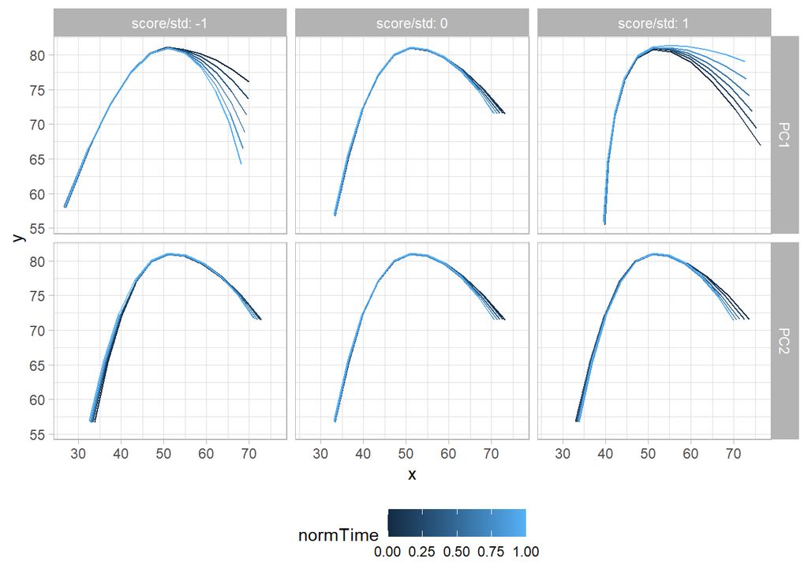

```r
FPCA_knot_time_curves_plot
```

PC1 explains 97% of the variance, PC2 explains 1.1% of the variance.

Figure 30: Distribution of the first 2 PC scores by Category

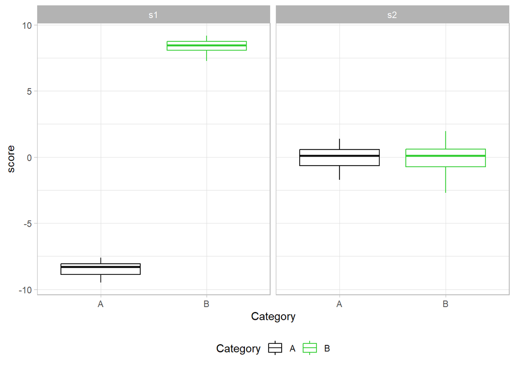

```r
FPCA_knot_time_scores_plot
```

A linear regression model predicting `s1` from `Category` is then fitted, which provides the predicted clips below.

Figure 31: Reconstructed clips by Category, based on regression model: s1 ~ Category

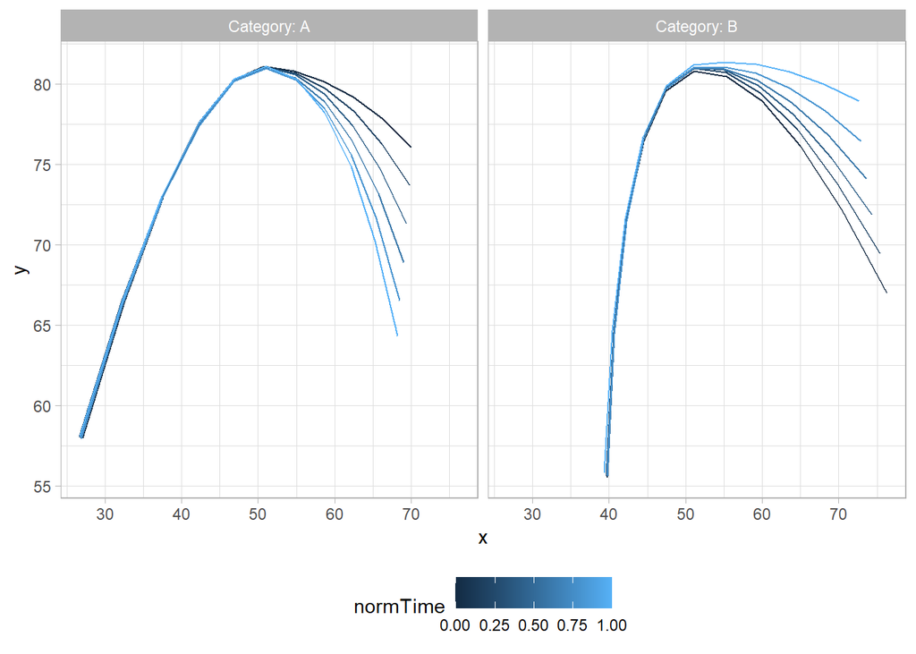

```r
FPCA_knot_time_pred_plot
```

# Citation information

For attribution, please cite this work as:

Michele Gubian (2025) *Analysis of Uni- and Multi-Dimensional Contours with GAMs and Functional PCA: an Application to Ultrasound Tongue Imaging* Version 1.0.0. Available from GitHub: [download page](https://github.com/uasolo/FPCA-phonetics-workshop/blob/master/presentations/UTI/UTI_analysis_code.html)

## References

Coretta, Stefano & Georges Sakr. 2025. Multivariate Analyses of Tongue Contours from Ultrasound Tongue Imaging. Draft V0.2. https://stefanocoretta.github.io/mv_uti/.

Gubian, Michele, Francisco Torreira & Lou Boves. 2015. Using functional data analysis for investigating multidimensional dynamic phonetic contrasts. *Journal of Phonetics* 49. Elsevier, 16–40.

Wieling, Martijn. 2018. Analyzing dynamic phonetic data using generalized additive mixed modeling: A tutorial focusing on articulatory differences between L1 and L2 speakers of english. *Journal of Phonetics* 70. Elsevier, 86–116.

Wieling, Martijn, Fabian Tomaschek, Denis Arnold, Mark Tiede, Franziska Bröker, Samuel Thiele, Simon N Wood & R Harald Baayen. 2016. Investigating dialectal differences using articulography. *Journal of Phonetics* 59. Elsevier, 122–143.

Wrench, Alan & Jonathan Balch-Tomes. 2022. Beyond the edge: Markerless pose estimation of speech articulators from ultrasound and camera images using DeepLabCut. *Sensors* 22(3). MDPI, 1133.